# Introduction

# Research Question

How user reviews of an Airbnb rental reflect its rating?

Does text reflect the actual overall rating of an Airbnb listing?

# Exploratory and Descriptive Analysis

```python
df_info.describe()
```

|  | listing_id | host_since | response_time | response_rate | acceptance_rate | latitude | longitude | property_type | room_type | accommodates | ... | availability_365 | number_of_reviews | rating | accuracy | cleanliness | checkin | communication | location | value | neighbourhood_lst |
| --- | --- | --- | --- | --- | --- | --- | --- | --- | --- | --- | --- | --- | --- | --- | --- | --- | --- | --- | --- | --- | --- |
| count | 7.381000e+03 | 7367.000000 | 7381.000000 | 6862.000000 | 7067.000000 | 7381.000000 | 7381.000000 | 7381.000000 | 7381.000000 | 7381.000000 | ... | 7381.000000 | 7381.000000 | 7381.000000 | 7381.000000 | 7381.000000 | 7381.000000 | 7381.000000 | 7381.000000 | 7381.000000 | 7381.000000 |
| mean | 2.555843e+07 | 45919.955613 | 3.404959 | 95.411979 | 89.186359 | 32.768891 | -117.188192 | 13.786750 | 0.395204 | 4.813846 | ... | 186.830511 | 55.771169 | 94.972361 | 9.672944 | 9.566861 | 9.813304 | 9.788917 | 9.811814 | 9.440049 | 50.975884 |
| std | 1.342662e+07 | 22530.364099 | 1.150502 | 13.787476 | 20.183483 | 0.063010 | 0.064563 | 10.912341 | 0.808675 | 3.122916 | ... | 120.530046 | 78.684369 | 7.304770 | 0.763540 | 0.769001 | 0.638928 | 0.653854 | 0.583839 | 0.850532 | 22.174535 |
| min | 2.996700e+04 | 195.000000 | 0.000000 | 0.000000 | 0.000000 | 32.531580 | -117.281430 | 0.000000 | 0.000000 | 1.000000 | ... | 0.000000 | 1.000000 | 20.000000 | 2.000000 | 2.000000 | 2.000000 | 2.000000 | 2.000000 | 2.000000 | 0.000000 |
| 25% | 1.485837e+07 | 30698.000000 | 3.000000 | 97.000000 | 90.000000 | 32.728890 | -117.250760 | 8.000000 | 0.000000 | 2.000000 | ... | 79.000000 | 7.000000 | 93.000000 | 10.000000 | 9.000000 | 10.000000 | 10.000000 | 10.000000 | 9.000000 | 41.000000 |
| 50% | 2.551762e+07 | 41097.000000 | 4.000000 | 100.000000 | 98.000000 | 32.761320 | -117.185660 | 12.000000 | 0.000000 | 4.000000 | ... | 178.000000 | 24.000000 | 97.000000 | 10.000000 | 10.000000 | 10.000000 | 10.000000 | 10.000000 | 10.000000 | 54.000000 |
| 75% | 3.799765e+07 | 60707.000000 | 4.000000 | 100.000000 | 100.000000 | 32.797920 | -117.146020 | 13.000000 | 0.000000 | 6.000000 | ... | 304.000000 | 74.000000 | 99.000000 | 10.000000 | 10.000000 | 10.000000 | 10.000000 | 10.000000 | 10.000000 | 66.000000 |
| max | 4.587940e+07 | 110811.000000 | 4.000000 | 100.000000 | 100.000000 | 33.085820 | -116.935710 | 61.000000 | 3.000000 | 16.000000 | ... | 365.000000 | 743.000000 | 100.000000 | 10.000000 | 10.000000 | 10.000000 | 10.000000 | 10.000000 | 10.000000 | 101.000000 |

8 rows × 24 columns

```
(-117.3009741, -116.8901439, 32.50241355, 33.144075449999995)
```

[figure not shown]

```python
fig, ax = plt.subplots(1, 1, figsize=(5, 5))
divider = make_axes_locatable(ax)
df_geo.plot(ax=ax)
geo_df.plot("price_transform", ax=ax, cmap="plasma", markersize=5, legend=True, legend_kwds={"label": "Price Transformed by Log Base 10","orientation": "horizontal"})
ax.set_title(label="Airbnb Geographical Price Distribution in San Diego County")
ax.get_xaxis().set_visible(False)
ax.get_yaxis().set_visible(False)
fig.patch.set_visible(False)
ax.axis("off")
```

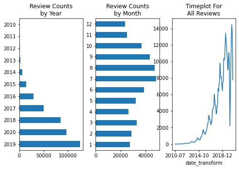

```python
fig = plt.figure(figsize=(8,5))
ax = fig.add_subplot(1, 3, 1)
ax.set_title(label="Review Counts\nby Year")
df["date_transform_year"].value_counts().sort_values(ascending=False).plot(kind="barh", ax=ax)
ax = fig.add_subplot(1, 3, 2)
ax.set_title(label="Review Counts\nby Month")
df["date_transform_month"].value_counts().sort_index().plot(kind="barh", ax=ax)
ax = fig.add_subplot(1, 3, 3)
ax.set_title(label="Timeplot For\nAll Reviews")
ax.set_xlabel("date")
date_count_df["rating"].plot(ax=ax)
```

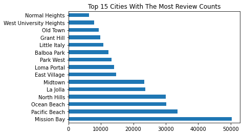

```python
plt.title(label="Top 15 Cities With The Most Review Counts")
geo_df["neighbourhood"].value_counts(ascending=False)[:15].plot.barh()
```

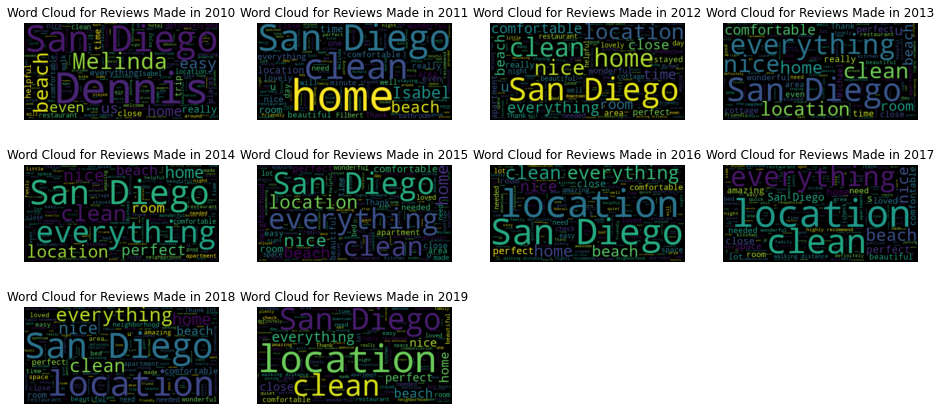

```python
fig = plt.figure(figsize=(16, 10))
for i in range(0, 10):
    year = 2010 + i
    title = "Word Cloud for Reviews Made in " + str(year)
    ax = fig.add_subplot(4, 4, i + 1)
    plt.title(label=title)
    wc = WordCloud(stopwords=NEW_STOPWORDS).generate(str(words_by_year[list(words_by_year.keys())[i]]))
    ax.imshow(wc, interpolation="bilinear")
    ax.axis("off")
```

```
(-117.30097409999999, -116.89014389999998, 32.5058523, 33.1439117)
```

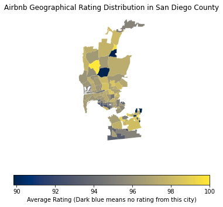

```python
fig, ax = plt.subplots(1, 1, figsize=(6, 6))
final_df.plot("rating", ax=ax, cmap="cividis", markersize=5, legend=True, legend_kwds={"label": "Average Rating (Dark blue means no rating from this city)","orientation": "horizontal"})
ax.set_title(label="Airbnb Geographical Rating Distribution in San Diego County")
ax.get_xaxis().set_visible(False)
ax.get_yaxis().set_visible(False)
fig.patch.set_visible(False)
ax.axis("off")
```

```
(-117.30097409999999, -116.89014389999998, 32.5058523, 33.1439117)
```

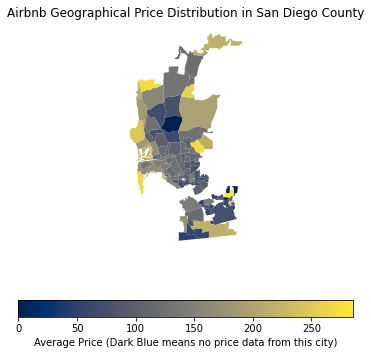

```python
fig, ax = plt.subplots(1, 1, figsize=(6, 6))
final_df.plot("price", ax=ax, cmap="cividis", markersize=5, legend=True, legend_kwds={"label": "Average Price (Dark Blue means no price data from this city)", "orientation": "horizontal",})
ax.set_title(label="Airbnb Geographical Price Distribution in San Diego County")
ax.get_xaxis().set_visible(False)
ax.get_yaxis().set_visible(False)
fig.patch.set_visible(False)
ax.axis("off")
```

## Predictions

##### Sentiment Analysis

```python
mse_sentiment_l_r, mse_sentiment_svm_con
```

```
(63.25210661173253, 70.78116531165311)
```

```python
acc_sentiment_log_r, acc_sentiment_svm_cla
```

```
(0.43360433604336046, 0.49525745257452575)
```

##### tfidf

```python
mse_tfidf_l_r, mse_tfidf_svm_con
```

```
(81.68163379979633, 120.35704607046071)
```

```python
acc_tfidf_log_r, acc_tfidf_svm_cla
```

```
(0.6646341463414634, 0.5968834688346883)
```

##### combine sentiment score and tfidf

```python
mse_l_r, mse_svm_con
```

```
(59.53680345012333, 72.95663956639567)
```

```python
acc_log_r, acc_svm_cla
```

```
(0.676829268292683, 0.5914634146341463)
```

# Metrics

```python
mse_sentiment_l_r, mse_sentiment_svm_con, mse_tfidf_l_r, mse_tfidf_svm_con, mse_l_r, mse_svm_con
```

```
(63.25210661173253,
 70.78116531165311,
 81.68163379979633,
 120.35704607046071,
 59.53680345012333,
 72.95663956639567)
```

```python
acc_sentiment_log_r, acc_sentiment_svm_cla, acc_tfidf_log_r, acc_tfidf_svm_cla, acc_log_r, acc_svm_cla
```

```
(0.43360433604336046,
 0.49525745257452575,
 0.6646341463414634,
 0.5968834688346883,
 0.676829268292683,
 0.5914634146341463)
```

```
For linear regression predicting exact score:
 	sentiment score: predict lower than actual: 629, predict higher than actual: 847
 	tfidf score: predict lower than actual: 635, predict higher than actual: 841
	both: predict lower than actual: 679, predict higher than actual: 797
For svm predicting exact score:
 	sentiment score: predict lower than actual: 557, predict higher than actual: 919
 	tfidf score: predict lower than actual: 734, predict higher than actual: 742
	both: predict lower than actual: 713, predict higher than actual: 763
For logistic regression interval:
 	sentiment score: predict lower than actual: 253, predict higher than actual: 1223
 	tfidf score: predict lower than actual: 299, predict higher than actual: 1177
	both: predict lower than actual: 288, predict higher than actual: 1188
For svm predicting interval:
 	sentiment score: predict lower than actual: 521, predict higher than actual: 955
 	tfidf score: predict lower than actual: 361, predict higher than actual: 1115
	both: predict lower than actual: 375, predict higher than actual: 1101
```

# Conclusion & Discussion

After trying out different types of text analysis and regressions, the best we can get is a prediction model with an accuracy rate of 67%. This accuracy rate is not very high but it is coherent with our hypothesis: we can find some correlations between reviews and ratings, but customers are less likely to leave direct harsh comments in their reviews, or in another word, under a text environment. Therefore, we can conclude that user reviews don't fully reflect the actual ratings of Airbnb rentals. To find a high-quality place, customers should not blindly trust user reviews, instead, they should also take other features into their consideration. Furthermore, we found that by combining TFIDF with sentiment scores, we could improve the prediction accuracy of our model. It makes sense since the property of TFIDF allows us to select words that are particularly important for certain documents. It could make the analysis more representative and targeted.